# MC integration

Aishameriane Schmidt

Last update: March 24, 2018

# Examples of MC integration

Carregando pacotes.

```r
chooseCRANmirror(graphics = FALSE, ind = 10)
if (!require("pacman")) install.packages("pacman")
pacman::p_load(ggplot2,latex2exp,metRology,reshape2,gridExtra)
```

## Exemple 1: Integrating a deterministic function

Assume that you want to integrate $I = \int_1^2 \exp(\theta)d\theta$ without using an analytical result.

Reinterpret $I$ as an expectation with respect to $\theta \sim U(1,2)$ (chosen in a convenient way between the integration limits). We know that the density of $Uniform[a,b]$ is $\frac{1}{b-a}$, such that $p_U(\theta) = 1/(2-1)$. This gives us:

$$I = \int\limits_1^2 \exp\{\theta \} d\theta = (2-1)\int\limits_1^2 \exp\{\theta \}\frac{1}{2-1}d \theta = (2-1) \mathbb{E}_{\mathcal{U}}[\exp\{\theta\}]$$
To approximate the integral, simulate $S$ observations of $\theta \sim U(1,2)$ and approximate $\mathbb{E}[\exp(\theta)]$ using the sample mean:

```r
# Fiz the random seed
set.seed(1234)

# Draw 1000 values from a uniform(1,2) and store in a vector
theta <- runif(1000,min = 1, max = 2)
head(theta)
```

```
## [1] 1.113703 1.622299 1.609275 1.623379 1.860915 1.640311
```

```r
# Compute the exponential
exp_theta <- exp(theta)
head(exp_theta)
```

```
## [1] 3.045617 5.064723 4.999184 5.070196 6.429620 5.156771
```

```r
# Do the sum of the values and divide by S
I_n <- (sum(exp_theta))/length(theta)
I_n
```

```
## [1] 4.708025
```

## Exemple 2: Cumulative density of the normal distribution

The CDF of the standard normal is given by
$$\Phi(\theta)=\int_{-\infty}^{x}\!\frac{1}{\sqrt{2\pi}}e^{\theta^2/2}\,d\theta$$
but this does not have closed formula, which is an interesting candidate for us to solve using MC integration. If we sample $\theta^i\sim N(0,1)$, then

$$\Phi(t)=\int_{-\infty}^{t}\!\frac{1}{\sqrt{2\pi}}e^{\theta^2/2}\,d\theta\approx\widehat{\Phi}_N(t)=\frac{1}{N}\sum_{i=1}^{N}1{\hskip -2.5 pt}\hbox{I}(\theta^{i}\leq t).$$

Note that $\widehat{\Phi}_N(t)$ is a Binomial random variable, so its variance is given by $\Phi(t)(1-\Phi(t))/N$, because:

$$Var[\widehat{\Phi}_N(t)] = Var \left[\frac{1}{N}\sum_{i=1}^{N}1{\hskip -2.5 pt}\hbox{I}(\theta^{i}\leq t) \right] = \frac{1}{N^2} \sum_{i=1}^{N} Var[1{\hskip -2.5 pt}\hbox{I}(\theta^{i}\leq t)] = \frac{1}{N^2} \sum_{i=1}^{N}\Phi(t)(1-\Phi(t)) = \frac{1}{N^2} N\Phi(t)(1-\Phi(t)) = \frac{1}{N} \Phi(t)(1-\Phi(t))$$

Values of $t$ close to zero imply that the variance of $\widehat{\Phi}_N(t)$ is $1/4N$, so we need $200.000$ to get a precision of 4 digits.

```r
# seed
set.seed(1235)

# Vector for the theta values
# Cria um vetor para theta
theta<-rep(0,1)

# fix t
# Fixa um t
t <- 0

# Creates a vector for the indicator function
# Cria um vetor para as indicadoras
indicadora <- rep(0,200000)

# Vector to store the draws of theta
# Gera um vetor para guardar os thetas
thetas<-rep(0,length(indicadora))

# Get a random draw from a standard normal and compares with t
# Gera um valor aleat?rio da normal padr?o e compara com o valor de t
for (i in 1:length(indicadora)){
  theta<-rnorm(1, mean = 0, sd = 1)
  ifelse(theta <= t, indicadora[i] <- 1, indicadora[i]<-0)
  thetas[i]<-theta
}

g_chapeu<-sum(indicadora)/length(indicadora)
sigma_chapeu<-(1/length(indicadora))*sum((thetas-g_chapeu)^2)
desv_pad_num<-sqrt(sigma_chapeu)/(sqrt(length(indicadora)))
```

If we compare the value from the normal table 0.5 with our approximated value, 0.498735, the difference is 0.001265. The value of $\hat{\sigma}_g^2$ is 1.2487, thus the numerical standard deviation, given by $\frac{\hat{\sigma}_g}{\sqrt{S}}$, is 0.0025.

To know effectively how good this procedure (after all could be that we were lucky), we need to sample several times this value.

```r
# Cria um vetor para theta
theta<-rep(0,1)

# Fixa um t
t <- 0

# Cria um vetor para as indicadoras
indicadora <- rep(0,5000)

# Cria um vetor para as estimativas
agregado <- rep(0,10000)

# Gera 1000 valores aleat?rios da normal padr?o e compara com o valor de t
# N?o ? muito eficiente colocar for dentro de for, mas ? o que tem pra hoje.
for (j in 1:10000) {
  for (i in 1:length(indicadora)){
    theta<-rnorm(1, mean = 0, sd = 1)
    ifelse(theta <= t, indicadora[i] <- 1, indicadora[i]<-0)
  }
agregado[j]<-sum(indicadora)/length(indicadora)
}
```

The mean of our estimates is 0.5001 and the standard deviation is 0.0071.

We can see in the figure below how in fact the several realizations of $\hat{g}_S(\theta)$ have a similar behavior of a normal distribution centered in $0.5$:

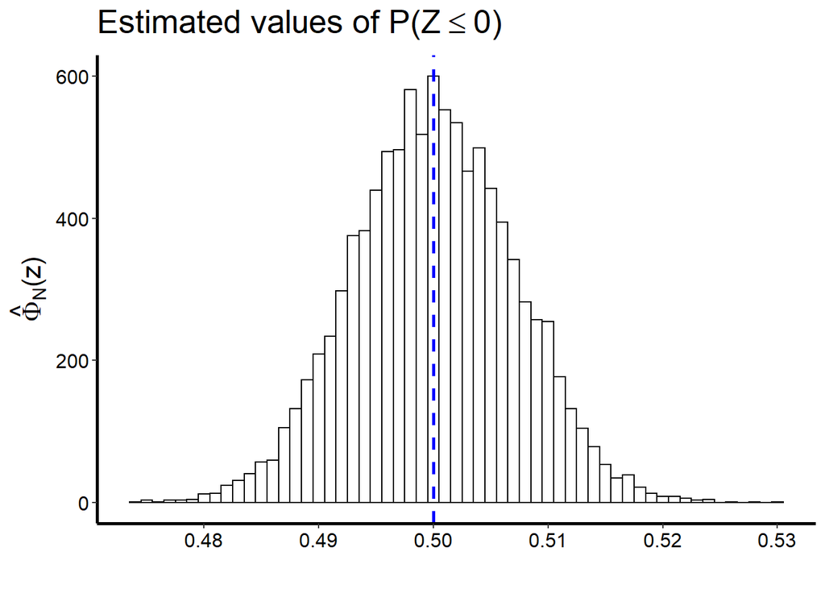

To see how to generate the Figure, check the code [here](https://github.com/aishameriane/Stuff/blob/master/MC%20integration%20examples.Rmd).

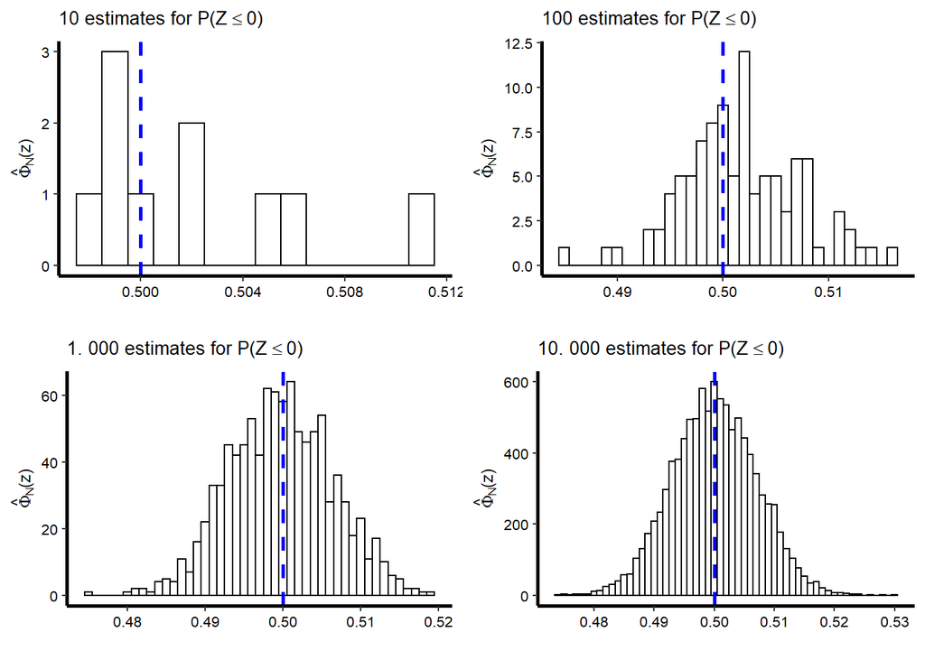

```r
y<-agregado

x1<-seq(.45,.55,length.out = 10)
dados1<-data.frame(x1,y[1:10])

x2<-seq(.45,.55,length.out = 100)
dados2<-data.frame(x2,y[1:100])

x3<-seq(.45,.55,length.out = 1000)
dados3<-data.frame(x3,y[1:1000])

x4<-seq(.45,.55,length.out = 10000)
dados4<-data.frame(x4,y[1:10000])


p1 <- ggplot(dados1, aes(x = y[1:10])) +
        geom_histogram(color = "black", fill="white", binwidth = .001)+
        ylab(TeX("$\\hat{\\Phi}_N(\\z)$")) +
        xlab("") +
        ggtitle(TeX("10 estimates for $P(Z \\leq 0)$")) +
        scale_colour_brewer(palette="Set1") +
        theme(axis.line = element_line(size=1, colour = "black"),
              panel.grid.major = element_blank(),
              panel.grid.minor = element_blank(),
              panel.border = element_blank(),
              panel.background = element_blank(),
              plot.title=element_text(size = 10),
              text=element_text(size = 9),
              axis.text.x=element_text(colour="black", size = 8),
              axis.text.y=element_text(colour="black", size = 8))
p1 <- p1 + geom_vline(aes(xintercept=pnorm(0,mean=0,sd=1)),
            color="blue", linetype="dashed", size=1)

p2 <- ggplot(dados2, aes(x = y[1:100])) +
        geom_histogram(color = "black", fill="white", binwidth = .001)+
        ylab(TeX("$\\hat{\\Phi}_N(\\z)$")) +
        xlab("") +
        ggtitle(TeX("100 estimates for $P(Z \\leq 0)$")) +
        scale_colour_brewer(palette="Set1") +
        theme(axis.line = element_line(size=1, colour = "black"),
              panel.grid.major = element_blank(),
              panel.grid.minor = element_blank(),
              panel.border = element_blank(),
              panel.background = element_blank(),
              plot.title=element_text(size = 10),
              text=element_text(size = 9),
              axis.text.x=element_text(colour="black", size = 8),
              axis.text.y=element_text(colour="black", size = 8))
p2 <- p2 + geom_vline(aes(xintercept=pnorm(0,mean=0,sd=1)),
            color="blue", linetype="dashed", size=1)

p3 <- ggplot(dados3, aes(x = y[1:1000])) +
        geom_histogram(color = "black", fill="white", binwidth = .001)+
        ylab(TeX("$\\hat{\\Phi}_N(\\z)$")) +
        xlab("") +
        ggtitle(TeX("1.000 estimates for $P(Z \\leq 0)$")) +
        scale_colour_brewer(palette="Set1") +
        theme(axis.line = element_line(size=1, colour = "black"),
              panel.grid.major = element_blank(),
              panel.grid.minor = element_blank(),
              panel.border = element_blank(),
              panel.background = element_blank(),
              plot.title=element_text(size = 10),
              text=element_text(size = 9),
              axis.text.x=element_text(colour="black", size = 8),
              axis.text.y=element_text(colour="black", size = 8))
p3 <- p3 + geom_vline(aes(xintercept=pnorm(0,mean=0,sd=1)),
            color="blue", linetype="dashed", size=1)

p4 <- ggplot(dados4, aes(x = y[1:10000])) +
        geom_histogram(color = "black", fill="white", binwidth = .001)+
        ylab(TeX("$\\hat{\\Phi}_N(\\z)$")) +
        xlab("") +
        ggtitle(TeX("10.000 estimates for $P(Z \\leq 0)$")) +
        scale_colour_brewer(palette="Set1") +
        theme(axis.line = element_line(size=1, colour = "black"),
              panel.grid.major = element_blank(),
              panel.grid.minor = element_blank(),
              panel.border = element_blank(),
              panel.background = element_blank(),
              plot.title=element_text(size = 10),
              text=element_text(size = 9),
              axis.text.x=element_text(colour="black", size = 8),
              axis.text.y=element_text(colour="black", size = 8))
p4 <- p4 + geom_vline(aes(xintercept=pnorm(0,mean=0,sd=1)),
            color="blue", linetype="dashed", size=1)

#pdf(file="C:\\Users\\Aishameriane\\OneDrive\\Documentos\\Mestrado Economia\\Bayesiana - 2018-01\\Notas de Aula 2018\\Imagens notas de aula\\Cap 4\\Fig-4.004.pdf", width = 10, height = 3)
grid.arrange(p1, p2, p3, p4, nrow = 2)
```

```r
#dev.off()
```

However, if we want to use $t$ less than $-4.5$, we need way more observations to get a decent estimate. This is because the occurence of these values is uncommon in the standard normal.

```r
# Seta a semente
set.seed(1234)

# Cria uma vari?vel para theta
theta<-rep(0,1)

# Fixa um t
t <- -4.5

# Cria um vetor para as indicadoras
indicadora <- rep(0,10000)

# Gera um valor aleat?rio da normal padr?o e compara com o valor de t
for (i in 1:length(indicadora)){
  theta<-rnorm(1, mean = 0, sd = 1)
  ifelse(theta <= t, indicadora[i] <- 1, indicadora[i]<-0)
}
```

Observe that in 10.000 realizations, we failed to find a value that is below $-4.5$, because the sum `sum(indicadora)` is equal to 0 (the indicator function). Although the probability is indeed low, this is not equal to zero: $\mathbb{P}(X \leq -4.5) =$ 3.397673110^{-6} and then this result using the standard MC integration is not realiable. We can do the same previous experiment and repeat this process to check the estimates:

```r
# Seta a semente
set.seed(1235)

# Uma vari?vel para theta
theta<-rep(0,1)

# Fixa um t
t <- -4.5

# Cria um vetor para as indicadoras
indicadora <- rep(0,10000)

# Cria um vetor para ir salvando as estimativas
agregado<-rep(0,10000)

# Gera um valor aleat?rio da normal padr?o e compara com o valor de t
for (j in 1:length(agregado)){
  for (i in 1:length(indicadora)){
    theta<-rnorm(1, mean = 0, sd = 1)
    ifelse(theta <= t, indicadora[i] <- 1, indicadora[i]<-0)
  }
agregado[j]<-sum(indicadora)/length(indicadora)
}
```

Again, we can plot the graph making several repetitions:

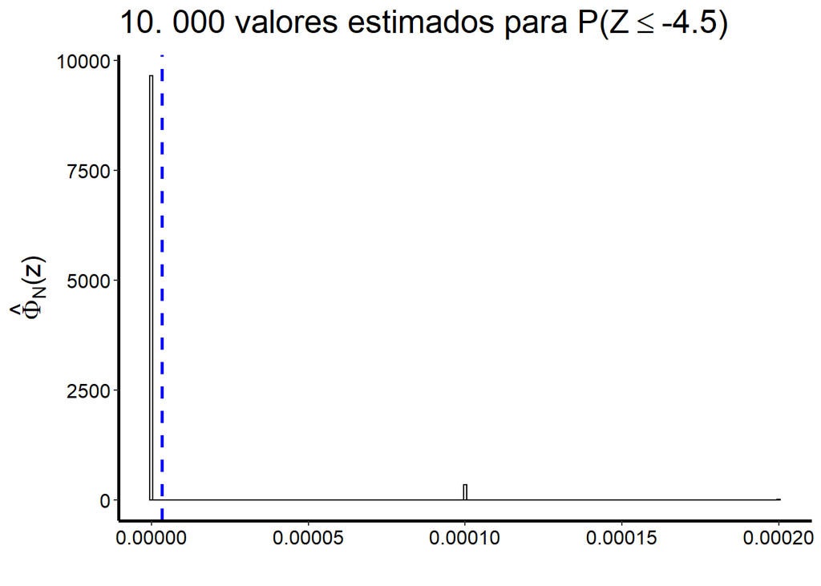

```r
x<-seq(.45,.55,length.out = 10000)
y<-agregado
dados<-data.frame(x,y)

p <- ggplot(dados, aes(x = y)) +
        geom_histogram(color = "black", fill="white", binwidth = .000001)+
        ylab(TeX("$\\hat{\\Phi}_N(z)$")) +
        xlab("") +
        ggtitle(TeX("10.000 valores estimados para $P(Z \\leq -4.5)$")) +
        scale_colour_brewer(palette="Set1") +
        theme(axis.line = element_line(size=1, colour = "black"),
              panel.grid.major = element_blank(),
              panel.grid.minor = element_blank(),
              panel.border = element_blank(),
              panel.background = element_blank(),
              plot.title=element_text(size = 20),
              text=element_text(size = 16),
              axis.text.x=element_text(colour="black", size = 12),
              axis.text.y=element_text(colour="black", size = 12))
p <- p + geom_vline(aes(xintercept=pnorm(-4.5,mean=0,sd=1)),
            color="blue", linetype="dashed", size=1)

#pdf(file="C:\\Users\\Aishameriane\\OneDrive\\Documentos\\Mestrado Economia\\Bayesiana - 2018-01\\Notas de Aula 2018\\Imagens notas de aula\\Cap 4\\Fig-4.004a.pdf", width = 10, height = 3)
p
```

```r
#dev.off()
```

From the Figure above, we observe that in fact the estimates are too concentrated around zero.

But then how can we compute the probability of rare events using MC methods? We can use **importance sampling**.

### Importance sampling

To get probabilities for rare events such as $\Phi(-4.5)$ using simple MC integration is rare, because we will get very few $\theta^i$ such that $1{\hskip -2.5 pt}\hbox{I}(\theta^{i}\leq -4.5)=1$, which implies that $\widehat{\Phi}_S(-4.5)=0$ even for higher values of $S$. But we can do a change of variable, for example, $v=\frac{1}{x}$:

$$\int_{-\infty}^{-4.5}\!\frac{1}{\sqrt{2\pi}}e^{\theta^2/2}\,d\theta=\int^{0}_{\frac{-1}{4.5}}\!\frac{\phi(1/v)}{v^2}dv=\frac{1}{4.5}\int^{0}_{\frac{-1}{4.5}}\!\frac{\phi(1/v)}{v^2}p_U(v)dv$$

We can sample $v_i\sim U(-1/4.5,0)$ so:

$$\int_{-\infty}^{-4.5}\!\frac{1}{\sqrt{2\pi}}e^{\theta^2/2}\,d\theta\approx\widehat{\Phi}^U_S(-4.5)=\frac{1}{S}\sum_{i=1}^S\frac{\phi(1/v^i)}{4.5v^{i^2}}$$

Note that the CDF of $v$, $p_U(v)=4.5$, is used in the denominator to compensate for the fact that we are not sampling from the original distribution (instead we use an ‘alternative’ distribution):

```r
# Define um tamanho de S e faz S retiradas de uma uniforme(-1/4.5, 0)
S<-20
vetor_v <- runif(S, min =(1/-4.5) , max = 0)

# Calcula a aproxima??o
numerador<- dnorm(1/vetor_v, mean=0, sd=1)
denominador<- 4.5*vetor_v^2
aproximacao<- (1/length(vetor_v))*sum(numerador/denominador)

# Calcula o desvio padr?o
sigma_chapeu<-(1/length(vetor_v))*sum((vetor_v-aproximacao)^2)
desv_pad_num<-sqrt(sigma_chapeu)/(sqrt(length(vetor_v)))
```

Our estimated value is 0, while the true value is $\mathbb{P}(X \leq -4.5) =$ 3.397673110^{-6}. We can also compute the numerical standard deviation: $\frac{\hat{\sigma}_g}{\sqrt{S}}=$ 0.0296.

Again, we can generate several estimates:

```r
# Define um tamanho de S e faz S retiradas de uma uniforme(-1/4.5, 0)
S<-10000

# Cria os vetores que v?o ser usados no la?o for
vetor_v<-seq(0,S)
numerador<-seq(0,S)
denominador<-seq(0,S)
estimativas<-seq(1,5000)

for (j in 1:length(estimativas)){
    vetor_v <- runif(S, min =(1/-4.5) , max = 0)
    numerador<- dnorm(1/vetor_v, mean=0, sd=1)
    denominador<- 4.5*vetor_v^2
    aproximacao<- (1/length(vetor_v))*sum(numerador/denominador)
  estimativas[j]<-aproximacao
}

mean(estimativas)
```

```
## [1] 3.396387e-06
```

and plot the graph:

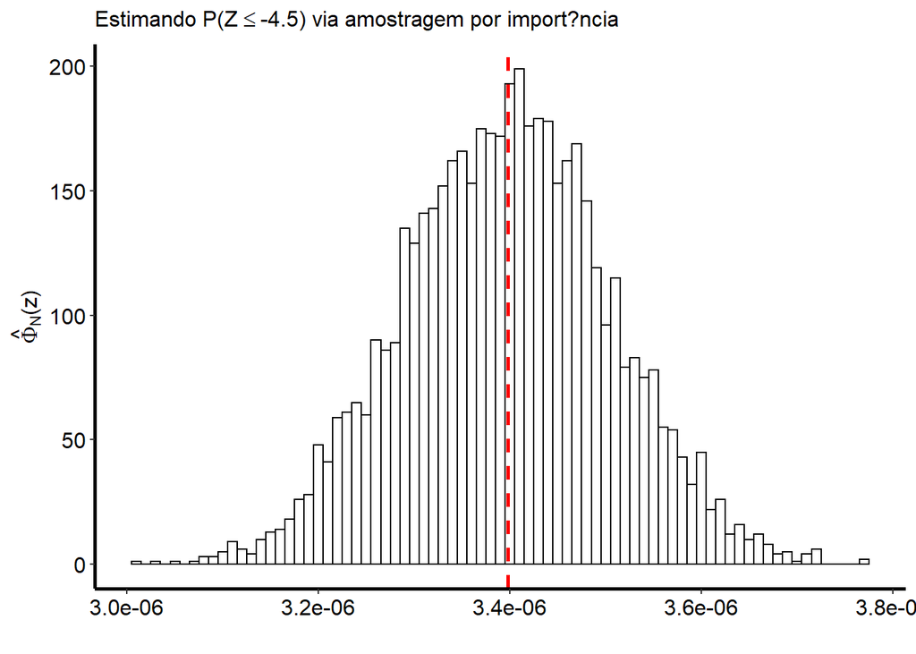

```r
x<-seq(.45,.55,length.out = 5000)
y<-estimativas
dados<-data.frame(x,y)

p <- ggplot(dados, aes(x = y)) +
        geom_histogram(color = "black", fill="white", binwidth = .00000001)+
        ylab(TeX("$\\hat{\\Phi}_N(z)$")) +
        xlab("") +
        ggtitle(TeX("Estimando $P(Z \\leq -4.5)$ via amostragem por import?ncia")) +
        scale_colour_brewer(palette="Set1") +
        theme(axis.line = element_line(size=1, colour = "black"),
              panel.grid.major = element_blank(),
              panel.grid.minor = element_blank(),
              panel.border = element_blank(),
              panel.background = element_blank(),
              plot.title=element_text(size = 12),
              text=element_text(size = 12),
              axis.text.x=element_text(colour="black", size = 12),
              axis.text.y=element_text(colour="black", size = 12))

p <- p + geom_vline(aes(xintercept=pnorm(-4.5,mean=0,sd=1)),
            color="red", linetype="dashed", size=1)

#pdf(file="C:\\Users\\Aishameriane\\OneDrive\\Documentos\\Mestrado Economia\\Bayesiana - 2018-01\\Notas de Aula 2018\\Imagens notas de aula\\Cap 4\\Fig-4.004b.pdf")
p
```

```r
#dev.off()
```

Here are the graphs for different sample sizes:

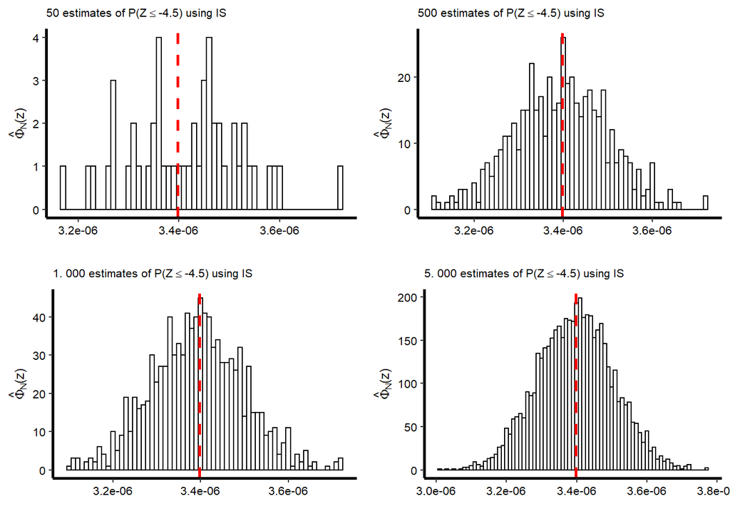

```r
y<-estimativas

x1<-seq(.45,.55,length.out = 50)
dados1<-data.frame(x1,y[1:50])

x2<-seq(.45,.55,length.out = 500)
dados2<-data.frame(x2,y[1:500])

x3<-seq(.45,.55,length.out = 1000)
dados3<-data.frame(x3,y[1:1000])

x4<-seq(.45,.55,length.out = 5000)
dados4<-data.frame(x4,y[1:5000])


p1 <- ggplot(dados1, aes(x = y[1:50])) +
        geom_histogram(color = "black", fill="white", binwidth = .00000001)+
        ylab(TeX("$\\hat{\\Phi}_N(\\z)$")) +
        xlab("") +
        ggtitle(TeX("50 estimates of $P(Z \\leq -4.5)$ using IS")) +
        scale_colour_brewer(palette="Set1") +
        theme(axis.line = element_line(size=1, colour = "black"),
              panel.grid.major = element_blank(),
              panel.grid.minor = element_blank(),
              panel.border = element_blank(),
              panel.background = element_blank(),
              plot.title=element_text(size = 8),
              text=element_text(size = 9),
              axis.text.x=element_text(colour="black", size = 8),
              axis.text.y=element_text(colour="black", size = 8))
p1 <- p1 + geom_vline(aes(xintercept=pnorm(-4.5,mean=0,sd=1)),
            color="red", linetype="dashed", size=1)

p2 <- ggplot(dados2, aes(x = y[1:500])) +
        geom_histogram(color = "black", fill="white", binwidth = .00000001)+
        ylab(TeX("$\\hat{\\Phi}_N(\\z)$")) +
        xlab("") +
        ggtitle(TeX("500 estimates of $P(Z \\leq -4.5)$ using IS")) +
        scale_colour_brewer(palette="Set1") +
        theme(axis.line = element_line(size=1, colour = "black"),
              panel.grid.major = element_blank(),
              panel.grid.minor = element_blank(),
              panel.border = element_blank(),
              panel.background = element_blank(),
              plot.title=element_text(size = 8),
              text=element_text(size = 9),
              axis.text.x=element_text(colour="black", size = 8),
              axis.text.y=element_text(colour="black", size = 8))
p2 <- p2 + geom_vline(aes(xintercept=pnorm(-4.5,mean=0,sd=1)),
            color="red", linetype="dashed", size=1)

p3 <- ggplot(dados3, aes(x = y[1:1000])) +
        geom_histogram(color = "black", fill="white", binwidth = .00000001)+
        ylab(TeX("$\\hat{\\Phi}_N(\\z)$")) +
        xlab("") +
        ggtitle(TeX("1.000 estimates of $P(Z \\leq -4.5)$ using IS")) +
        scale_colour_brewer(palette="Set1") +
        theme(axis.line = element_line(size=1, colour = "black"),
              panel.grid.major = element_blank(),
              panel.grid.minor = element_blank(),
              panel.border = element_blank(),
              panel.background = element_blank(),
              plot.title=element_text(size = 8),
              text=element_text(size = 9),
              axis.text.x=element_text(colour="black", size = 8),
              axis.text.y=element_text(colour="black", size = 8))
p3 <- p3 + geom_vline(aes(xintercept=pnorm(-4.5,mean=0,sd=1)),
            color="red", linetype="dashed", size=1)

p4 <- ggplot(dados4, aes(x = y[1:5000])) +
        geom_histogram(color = "black", fill="white", binwidth = .00000001)+
        ylab(TeX("$\\hat{\\Phi}_N(\\z)$")) +
        xlab("") +
        ggtitle(TeX("5.000 estimates of $P(Z \\leq -4.5)$ using IS")) +
        scale_colour_brewer(palette="Set1") +
        theme(axis.line = element_line(size=1, colour = "black"),
              panel.grid.major = element_blank(),
              panel.grid.minor = element_blank(),
              panel.border = element_blank(),
              panel.background = element_blank(),
              plot.title=element_text(size = 8),
              text=element_text(size = 9),
              axis.text.x=element_text(colour="black", size = 8),
              axis.text.y=element_text(colour="black", size = 8))
p4 <- p4 + geom_vline(aes(xintercept=pnorm(-4.5,mean=0,sd=1)),
            color="red", linetype="dashed", size=1)
#pdf(file="C:\\Users\\Aishameriane\\OneDrive\\Documentos\\Mestrado Economia\\Bayesiana - 2018-01\\Notas de Aula 2018\\Imagens notas de aula\\Cap 4\\Fig-4.004.pdf", width = 10, height = 3)
grid.arrange(p1, p2, p3, p4, nrow = 2)
```

```r
#dev.off()
```

## Exemple 3 - Cauchy

**Obs:** numerical values in the text are obtained directly using R, check the code [here](https://github.com/aishameriane/Stuff/blob/master/MC%20integration%20examples.Rmd) to see the procedure. This example is an adaptation from Robert and Casella’s MC methods book.

We want to estimate the probability that a random variable $X$ with a Cauchy distribution with parameters $(0,1)$ is bigger than $2$. In other words, for $X \sim \mathcal{C}(0,1)$ we want to compute $\mathbb{P}(X \geq 2)$:

$$\begin{equation}\tag{23}
p = \mathbb{P}(X \geq 2) = \int\limits_2^\infty \frac{1}{\pi(1+x^2)}dx
\end{equation}$$

Imagine that the values in (23) are not easily obtained. Then we can use the idea of IS and for a random sample $X_1, \cdots, X_m$ of the distribution of $X$, we can approximate $p$ with different ways.

### Method 1

$$\begin{equation}\tag{24}
p \approx \hat{p}_1 = \frac{1}{m}\sum\limits_{j=1}^m \mathbb{I}_{X_j > 2}
\end{equation}$$

The variance of the estimator $\hat{p}_1$ can be obtained as follows:

$$\begin{equation}\tag{25}
Var[\hat{p}_1] = Var\left[\frac{1}{m}\sum\limits_{j=1}^m \mathbb{I}_{X_j > 2} \right] = \frac{1}{m^2} \sum\limits_{j=1}^m \left( Var[\mathbb{I}_{X_j > 2]} \right) = \frac{1}{m^2}mp(1-p) = \frac{p(1-p)}{m}
\end{equation}$$

Since $\mathbb{P}(X \geq 2)=$ 0.15, the variance of the estimator in (24) will be given by $Var[\hat{p}_1] =$ 0.128 $/m$.

### Method 2

To have something with a smaller variance than the estimator in (24), we can change our estimator. Considering that the Cauchy(0,1) distribution is symmetric around zero, an estimate for $p$ would be:

$$\begin{equation}\tag{26}
p \approx \hat{p}_2 = \frac{1}{2m}\sum\limits_{j=1}^m \mathbb{I}_{|X_j| > 2}
\end{equation}$$

$$\begin{equation}\tag{27}
Var[\hat{p}_2] = Var\left[\frac{1}{2m}\sum\limits_{j=1}^m \mathbb{I}_{|X_j| > 2} \right] = \frac{1}{4m^2} \sum\limits_{j=1}^m \left( Var[\mathbb{I}_{|X_j| > 2]} \right) = \frac{1}{4m^2}\cdot 2mp(1-2p) = \frac{p(1-2p)}{2m}
\end{equation}$$

Using again the fact that $\mathbb{P}(X \geq 2)=$ 0.15, the variance of the estimator in (25) is given by $Var[\hat{p}_2] =$ 0.052 $/m$.

### Method 3

The two previous methods have some inefficiency: they generate values outiside the support we are interested in, which is $[2, + \infty)$. There “extra” terms are irrelevant for approximating $p$.

Knowing that $\mathbb{P}(X > 2) = 1-\mathbb{P}(X < 2)$ and $\mathbb{P}(X > 2|X>0) = \frac{1}{2}-\mathbb{P}(0< X < 2)$, we can think about writing $p$ as:

$$\begin{equation}\tag{28}
p = \frac{1}{2} - \int\limits_0^2 \frac{1}{\pi(1+x^2)}dx
\end{equation}$$

Consider now a random variable $X \sim \mathcal{U}(0,2)$. We know that $f_X(x)=\frac{1}{2-0}=\frac{1}{2}$. Then, multiplying the integral in (28) by $\frac{2}{2}$, we have:

$$\begin{equation}\tag{29}
p = \frac{1}{2} - \int\limits_0^2 \overbrace{\frac{2}{\pi(1+x^2)}}^{h(x)}\underbrace{\frac{1}{2}}_{\text{fdp de }X}dx = \frac{1}{2} - \int\limits_0^2 h(x) f_X(x) dx = \frac{1}{2} - \mathbb{E}[h(X)]
\end{equation}$$

The integral in (29) can be seen as an expectation of a function of $X$, i.e., using the unconcious statistician lemma we can see $p$ as an expectation. This means that we can use the LLN to approximate this using a sample mean:

$$\begin{equation*}
\hat{p}_3 = \frac{1}{2} - \frac{1}{m} \sum\limits_{j=1}^m h(U_j) = \frac{1}{2} - \frac{1}{m} \sum\limits_{j=1}^m \frac{2}{\pi}(1+U_j^2)
\end{equation*}$$

where $U_j \sim \mathcal{U}(0,2)$. To compute the variance of $\hat{p}_3$, we do:

$$\begin{align*}
Var(\hat{p}_3) &= 0 - Var\left(\frac{1}{m} \sum\limits_{j=1}^m h(U_j) \right)\\
&= \frac{1}{m^2} \sum\limits_{j=1}^m Var(h(U_j)) \\
&= \frac{1}{m^2} \cdot m Var(h(U_j)) \\
&= \frac{1}{m} Var(h(U_j))
\end{align*}$$

So we can use $Var(X) = \mathbb{E}(X^2)- \mathbb{E}(X)^2$ the expression in the expression above to obtain:

$$\begin{equation}\tag{30}
Var(\hat{p}_3) = \frac{1}{m} \mathbb{E}(h^2(U))- \mathbb{E}(h(U))
\end{equation}$$

Since $U \sim \mathcal{U}(0,2)$, these expectations are obtained computing integrals, for which we use trigonometric functions. Recall that $\int 1/(a^2+x^2) = (1/a) tan^{-1}(x/a) + c$, and compute the second integral as follows:

$$\begin{align*}
\mathbb{E}[h(U)] &= \int\limits_0^2 \underbrace{\frac{2}{\pi(1^2 + u^2)}}_{h(U)}\underbrace{\frac{1}{2}}_{\text{fdp de }U} du\\
&= \frac{1}{\pi}\int\limits_0^2 \frac{1}{\pi(1^2 + u^2)} du \\
&= \frac{1}{\pi}(tg^-1(u))\Big|_0^2\\
&= \frac{1}{\pi}tg^{-1}(2)
\end{align*}$$

Thus, $\mathbb{E}[h(U)] =$ 0.3524 so $\left(\mathbb{E}[h(U)]\right)^2=$ 0.1242.

In a similar manner,

$$\begin{align*}
\mathbb{E}[h^2(U)] &= \int\limits_0^2 \underbrace{\left(\frac{2}{\pi(1^2 + u^2)}\right)^2}_{h^2(U)}\underbrace{\frac{1}{2}}_{\text{fdp de }U} du = \frac{2+5tg^{-1}(2)}{5\pi^2}
\end{align*}$$

Therefore, $\mathbb{E}[h^2(U)] =$ 0.1527 and we get $Var(\hat{p}_3) = \frac{1}{m} \mathbb{E}(h^2(U))- \mathbb{E}(h(U)) =$ 0.0285 $/m$.

### Method 4

Consider now a r.v. $Y \sim \mathcal{U}(0,1/2)$. We know that $f_Y(y)=\frac{1}{1/2-0}=\frac{1}{1/2}=2$. We can do a transformation of variables in expression (23) using $Y=\frac{1}{X}$, which gives us

$$\begin{align*}
x &= \frac{1}{y}\\
dx &= -\frac{1}{y^{2}}=-y^{-2}\\
x=1/2 & \Rightarrow y=2\\
x\to \infty &\Rightarrow y=0
\end{align*}$$

Since the integration limits need to swap places, the integral receives a negative sign that will cancel out with the negative sign of $dx$, so (23) will be:

$$\begin{align*}
p = \mathbb{P}(X \geq 2) = \mathbb{P}(0 < Y < 1/2) = \int\limits_0^{\frac{1}{2}} \frac{y^{-2}}{\pi(1+y^{-2})}dy
\end{align*}$$

Note that $\frac{y^{-2}}{(1+y^{-2})} = \frac{1}{y^{2}(1+y^{-2})} = \frac{1}{y^{2}+y^{0}} = \frac{1}{1+ y^{2}}$ which allows us to express the above expression as:

$$\begin{align*}
p = \int\limits_0^{\frac{1}{2}} \frac{1}{\pi(1+y^{2})}dy
\end{align*}$$

Take $h(Y) = \frac{2}{\pi(1+y^2)}$. So $\frac{1}{4}h(Y) = \frac{2}{4\pi(1+y^2)} = \frac{1}{2}\frac{1}{\pi(1+y^2)}$, which is the expression of $p$. Therefore:

$$\begin{equation}\tag{31}
p = \int\limits_0^{\frac{1}{2}} \frac{1}{\pi(1+y^{2})}dy = \int\limits_0^{\frac{1}{2}} \frac{1}{\pi(1+y^{2})}\frac{2}{\underbrace{2}_{\text{fdp de }Y}}dy = 2\cdot\mathbb{E}\left(\frac{1}{4}h(Y)\right) =\frac{1}{2}\mathbb{E}(h(Y))
\end{equation}$$

The expectation in (31) can be approximated by a sample average:

$$\begin{equation}\tag{32}
\hat{p}_4 = \frac{1}{4m}\sum\limits_{j=1}^m h(Y_j)
\end{equation}$$

Using the same method, we compute the variance of $\hat{p}_4$:

$$\begin{equation*}
Var[\hat{p}_4] = \frac{1}{16m^2} \sum\limits_{j=1}^m Var[h(Y_j)] = \frac{m}{16m^2} Var[h(Y_j)] = \frac{Var[h(Y_j)]}{16m}
\end{equation*}$$

Since $Var[h(Y_j)] =\mathbb{E}[h^2(Y_j)] -\mathbb{E}[h(Y_j)]^2$, we use integration by parts to find each piece:

$$\begin{align*}
\mathbb{E}[h(Y_j)] = \frac{4}{\pi}tg^{-1}(1/2)\\
\mathbb{E}[h^2(Y_j)] = \frac{4(2+5 tg^{-1}(1/2))}{5\pi^2}
\end{align*}$$

Thus, $Var[h(Y_j)] =\mathbb{E}[h^2(Y_j)] -\mathbb{E}[h(Y_j)]^2=$ 9.37510^{-5} $/m$.

## Exemple 4 - t distribution

Suppose that we want to sample from $\theta \sim t(\nu, 0, 1)$ to compute:

$$\begin{equation*}
\int_{2.1}^\infty \theta^5 p(\theta|y)d\theta
\end{equation*}$$

where

$$\begin{equation*}
p(\theta|y) = \frac{\Gamma\left(\frac{\nu + 1}{2}\right)}{\sqrt{\nu \pi}\Gamma\left(\frac{\nu}{2}\right)}\left(1+\frac{\theta^2}{\nu} \right)^{-\frac{\nu+1}{2}}
\end{equation*}$$

We can compare different importance sampling functions

1. Cauchy: $\mathcal{C}(0,1)$;
2. Normal: $\mathcal{N}(0,1)$;
3. Uniforme: $\mathcal{U}(0, 1/2.1)$.

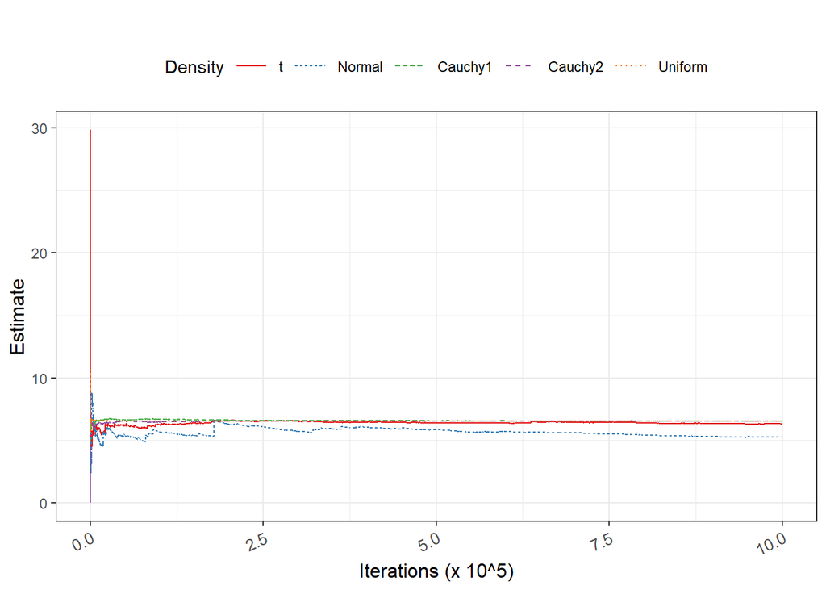

```r
set.seed(1234)

# Par?metros
Esse <- 1000000  # Size of the MC sample
den  <- 1:Esse   # Auxiliary vector
cut  <- 2.1      # Integration limit
df   <- 12       # Degrees of freedom

############ Using the original density ####################
t  <- rt(n = Esse, df = df)  # Sample S values from the t distribution
tt <- mean((t^5)*(t>cut))    # Estimate
tp <- cumsum((t^5)*(t>cut))/den  # Evolution of the estimate when S grows


############ Usando the gaussian density ####################
z   <- rnorm(n = Esse, mean = 0, sd = 1) # Draw S values from the normal distribution
fz  <- (z^5)*(dt(x = z, df = df)/dnorm(z))*(z>cut) # Evaluate the function in the realizations
zz  <- mean(fz) # MC estimate
zp  <- cumsum(fz)/den   # Evolution of the estimate when S grows


############ Using the Cauchy dist ####################
c   <- rcauchy(n = Esse, location = 0, scale = 1) # Sample from the Cauchy
fc  <- (c^5)*(dt(x=c, df = df)/dcauchy(c, location = 0, scale = 1))*(c>cut) # Evaluate the function in the realizations
cc  <- mean(fc) # MC estimate
cp  <- cumsum(fc)/den   # Evolution of the estimate when S grows


############ Using a t distribution with 1 DF ####################
c1   <- rt(n = Esse, df = 1) # The t with 1 DF is equal to a Cauchy
fc1  <- (c1^5)*(dt(x=c1, df = df)/dt(c1, df= 1))*(c1>cut) # Evaluate the function in the realizations
cc1  <- mean(fc1)
cp1  <- cumsum(fc1)/den   # Evolution of the estimate when S grows


############ Usando a densidade uniforme ####################
u    <- (1/cut)*runif(n = Esse) # Sample from the uniform (0,1/2.1) is equivalent to sample from the standard uniform and divide by 2.1 (Greenberg page 64)
u7   <- u^(-7)
tu   <- dt(1/u, df = df)
fu   <- u7*tu                   # Evaluate the function in the realizations
uu   <- mean(fu)                # MC estimate
up   <- cumsum(fu)/(cut*den)      # Evolution of the estimate when S grows


### Plota os gr?ficos
data_frame <- data.frame(den/10^5, tp, zp, cp, cp1, up)
names(data_frame) <- c("Density", "t", "Normal", "Cauchy1", "Cauchy2", "Uniform")
df2 <- melt(data = data_frame, id.vars = "Density")

p <- ggplot(df2, aes(Density, value, colour = variable)) +
  geom_line(alpha = 1, aes(linetype = variable))+
  labs(title="", y = "Estimate", x= "Iterations (x 10^5)", color = "Density")+
  scale_colour_brewer(palette = "Set1") +
  theme_bw()

p <- p + labs(linetype = "Density")
p <- p + labs(colour='Density')
p <- p + theme(legend.position="top", legend.key.size = unit(.8, "cm"), axis.text.x = element_text(angle=25, hjust = 1, size = 10), axis.title.y = element_text(size = 12), axis.title.x = element_text(size = 12))


#pdf(file="C:\\Users\\Aishameriane\\OneDrive\\Documentos\\Mestrado Economia\\Bayesiana - 2018-01\\Notas de Aula 2018\\Imagens notas de aula\\Cap 4\\Fig-4.006.pdf", width = 10, height = 6)
p
```

```r
#dev.off()
```